# Homework 02

## Question 1: Training and test error under a fixed design

Consider a linear regression problem with $n=100$ observations and $p=20$ available covariates. Generate one matrix $\mathbf X_{\mathrm{all}}\in\mathbb R^{n\times p}$ whose entries are independent $\mathcal N(0,1)$ random variables, and then keep this realized matrix fixed. Let

$$\beta_j=0.4^{\sqrt{j}},
\qquad j=1,\ldots,p,$$

and define

$$\boldsymbol\mu=\mathbf X_{\mathrm{all}}\boldsymbol\beta.$$

Generate one training response and one independent test response from

$$\begin{aligned}
\mathbf y
&=\boldsymbol\mu+\boldsymbol\epsilon,\\
\mathbf y^*
&=\boldsymbol\mu+\boldsymbol\epsilon^*,
\end{aligned}$$

where

$$\boldsymbol\epsilon,\boldsymbol\epsilon^*
\overset{\mathrm{ind}}{\sim}
\mathcal N_n(\mathbf 0,\mathbf I_n).$$

Here $\mathbf I_n$ is the $n\times n$ identity matrix.

For $m=0,1,\ldots,p$, fit a linear model with an intercept and the first $m$ columns of $\mathbf X_{\mathrm{all}}$ using $\mathbf y$. If $\widehat{\mathbf y}_m$ is its fitted mean vector, define

$$\operatorname{MSE}_{\mathrm{train},m}
=\frac{1}{n}
\left\lVert
\mathbf y-\widehat{\mathbf y}_m
\right\rVert_2^2,$$

and

$$\operatorname{MSE}_{\mathrm{test},m}
=\frac{1}{n}
\left\lVert
\mathbf y^*-\widehat{\mathbf y}_m
\right\rVert_2^2.$$

Repeat this process independently 200 times, keeping $\mathbf X_{\mathrm{all}}$ fixed.

Use seed `43202` before generating $\mathbf X_{\mathrm{all}}$ and the response errors. R and Python use different random-number generators, so their exact numerical values need not agree.

1. For each $m$, calculate the average training and test MSE over the 200 simulation runs. Plot both curves against $m$. Verify numerically that training MSE does not increase as predictors are added in each simulation run.
2. For the model containing the first $m$ predictors, write

$$\mathbf X_m
=
[\mathbf 1,\mathbf x_1,\ldots,\mathbf x_m],
\qquad
\mathbf H_m
=
\mathbf X_m
(\mathbf X_m^{\mathsf T}\mathbf X_m)^{-1}
\mathbf X_m^{\mathsf T}.$$

Here $\mathbf X_m\in\mathbb R^{n\times(m+1)}$ and $\mathbf H_m\in\mathbb R^{n\times n}$. The model has $m+1$ fitted coefficients, including the intercept. Define its **total squared approximation bias** as

$$B_m^2
=\left\lVert
(\mathbf I_n-\mathbf H_m)\boldsymbol\mu
\right\rVert_2^2.$$

Thus, $B_m^2/n$ is the mean squared approximation bias.

Calculate the two theoretical expectations

$$E\!\left(
\operatorname{MSE}_{\mathrm{train},m}
\mid \mathbf X_{\mathrm{all}}
\right)
=\frac{B_m^2}{n}+1-\frac{m+1}{n},$$

and

$$E\!\left(
\operatorname{MSE}_{\mathrm{test},m}
\mid \mathbf X_{\mathrm{all}}
\right)
=\frac{B_m^2}{n}+1+\frac{m+1}{n}.$$

Add these expectations to your plot and compare them with the simulation averages.

3. Add the test MSE curve from one simulation run to the plot. Explain why this single curve is less smooth than the average test MSE. Use the approximation-bias and estimation-variance terms in the expected test MSE to explain why training MSE cannot be used by itself to select the predictor count.

### My answer

**Show the starter code**

```python
import numpy as np
import matplotlib.pyplot as plt

rng = np.random.default_rng(43202)
n, p = 100, 20
X_all = rng.normal(size=(n, p))
beta = 0.4 ** np.sqrt(np.arange(1, p + 1))
mu = X_all @ beta
ones = np.ones((n, 1))

def design(m):
    return np.column_stack([ones, X_all[:, :m]]) if m > 0 else ones

runs = 200
train = np.zeros((runs, p + 1))
test = np.zeros((runs, p + 1))
for r in range(runs):
    y = mu + rng.normal(size=n)
    ystar = mu + rng.normal(size=n)
    for m in range(p + 1):
        Xm = design(m)
        b, *_ = np.linalg.lstsq(Xm, y, rcond=None)
        yhat = Xm @ b
        train[r, m] = np.mean((y - yhat) ** 2)
        test[r, m] = np.mean((ystar - yhat) ** 2)

train_avg, test_avg = train.mean(0), test.mean(0)
print("train MSE nonincreasing within every run:", bool(np.all(np.diff(train, axis=1) <= 1e-9)))
```

```
train MSE nonincreasing within every run: True
```

**Show the starter code**

```python
ms = np.arange(p + 1)
B2n = np.empty(p + 1)
for m in ms:
    Xm = design(m)
    H = Xm @ np.linalg.solve(Xm.T @ Xm, Xm.T)
    e = mu - H @ mu
    B2n[m] = e @ e / n
E_train = B2n + 1 - (ms + 1) / n
E_test = B2n + 1 + (ms + 1) / n

fig, ax = plt.subplots(figsize=(7, 4.4))
ax.plot(ms, train_avg, "o-", color="#1F5A94", ms=4, label="train (sim)")
```

**Show the starter code**

```python
ax.plot(ms, test_avg, "o-", color="#C84A16", ms=4, label="test (sim)")
```

**Show the starter code**

```python
ax.plot(ms, E_train, "--", color="#1F5A94", label="train (theory)")
```

**Show the starter code**

```python
ax.plot(ms, E_test, "--", color="#C84A16", label="test (theory)")
```

**Show the starter code**

```python
ax.plot(ms, test[0], color="#9AA0A6", alpha=0.9, label="test (one run)")
```

**Show the starter code**

```python
ax.set(xlabel="m", ylabel="MSE")
```

```
[Text(0.5, 0, 'm'), Text(0, 0.5, 'MSE')]
```

**Show the starter code**

```python
ax.legend(frameon=False, fontsize=8)
```

**Show the starter code**

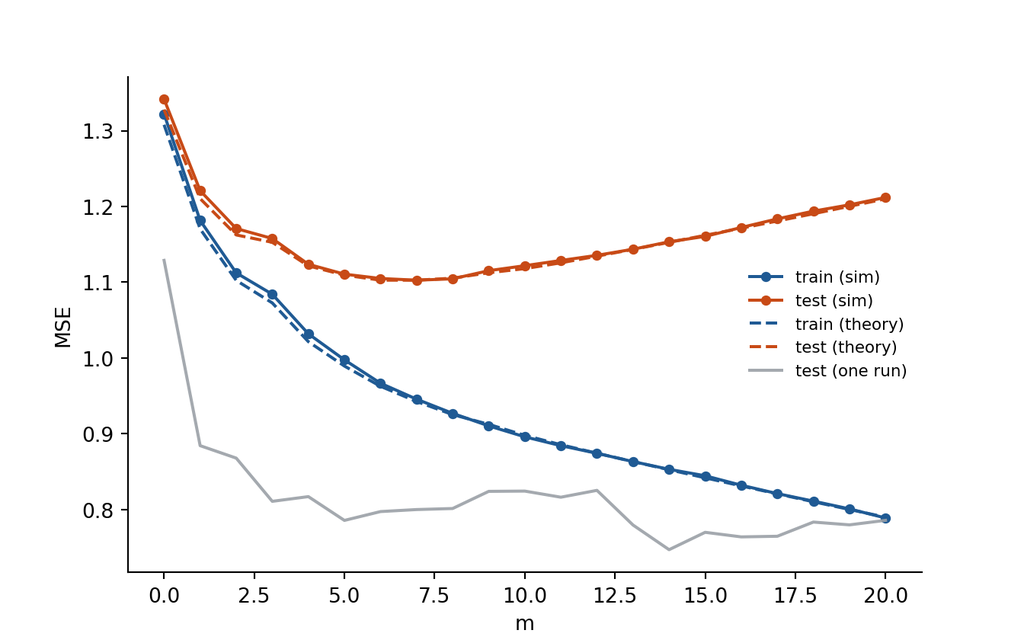

Training and test MSE vs model size: simulation against theory.

```python
ax.spines[["top", "right"]].set_visible(False)
plt.show()
```

**Show the starter code**

```python
print("test MSE minimized at m =", int(np.argmin(test_avg)))
```

```
test MSE minimized at m = 7
```

**a.** The check prints `True`: within every one of the 200 runs, training MSE never goes up as columns are added. That has to happen, since fitting with an extra column can only shrink the least-squares residual (the smaller model is nested inside the larger one). The averaged test curve instead dips and then climbs, bottoming out around $m=7$.

**b.** The theory curves (dashed) sit right on top of the simulation averages. Both share the same bias term $B_m^2/n$, and they split by $\pm(m+1)/n$: training sits below by $(m+1)/n$ and test sits above by the same amount. That gap is exactly twice the estimation cost of the extra coefficients, and it widens as $m$ grows.

**c.** The single grey run is choppy because it’s one draw of $\boldsymbol\epsilon^*$; averaging over 200 runs cancels that noise and leaves the smooth curve. Looking at the expected test MSE, $B_m^2/n + 1 + (m+1)/n$, adding predictors pushes the bias $B_m^2/n$ down but pushes the variance $(m+1)/n$ up, so there’s a sweet spot in the middle. Training MSE, $B_m^2/n + 1 - (m+1)/n$, has both terms *decreasing* in $m$, so it just keeps falling and never flags the point where variance starts to hurt. That’s why you can’t pick $m$ from training error alone.

## Question 2: Prediction error at one target point

Let $n=100$, $p=6$, and $\sigma^2=1$. Construct the fixed covariate matrix $\mathbf X_{\mathrm{all}}\in\mathbb R^{n\times p}$ with entries

$$(\mathbf X_{\mathrm{all}})_{ij}
=\sqrt{2}\cos\left\{
\frac{\pi j(i-\tfrac12)}{n}
\right\},
\qquad
i=1,\ldots,n,
\quad
j=1,\ldots,p.$$

Its columns satisfy

$$\mathbf 1^{\mathsf T}\mathbf X_{\mathrm{all}}=\mathbf 0^{\mathsf T},
\qquad
\frac{1}{n}\mathbf X_{\mathrm{all}}^{\mathsf T}\mathbf X_{\mathrm{all}}=\mathbf I_p.$$

Here $\mathbf I_p$ is the $p\times p$ identity matrix.

The following code shows a direct construction of $\mathbf X_{\mathrm{all}}$.

**R**

**Show the starter code**

```r
n <- 100
p <- 6
X_all <- outer(
  1:n, 1:p,
  function(i, j) sqrt(2) * cos(pi * j * (i - 0.5) / n)
)
```

**Python**

**Show the starter code**

```python
import numpy as np

n, p = 100, 6
i = np.arange(1, n + 1)[:, None]
j = np.arange(1, p + 1)[None, :]
X_all = np.sqrt(2) * np.cos(np.pi * j * (i - 0.5) / n)
```

Keep $\mathbf X_{\mathrm{all}}$ fixed and generate one training response from

$$\mathbf y
=\mathbf X_{\mathrm{all}}\boldsymbol\beta+\boldsymbol\epsilon,
\qquad
\boldsymbol\beta
=(0.5,0.5,0.5,0.5,0.5,0.5)^{\mathsf T},$$

where

$$\boldsymbol\epsilon
\sim
\mathcal N_n(\mathbf 0,\mathbf I_n).$$

Here $\mathbf I_n$ is the $n\times n$ identity matrix.

For $m=0,\ldots,p$, fit a linear model with an intercept and the first $m$ predictors. Consider prediction of the mean response at

$$\mathbf x_0=(0,1,0,0,1,0)^{\mathsf T}.$$

Write

$$\mu_0=\mathbf x_0^{\mathsf T}\boldsymbol\beta,$$

and let $\widehat\mu_{0,m}$ be the prediction from the model containing the first $m$ predictors. Here $x_{0j}$ denotes the $j$th coordinate of $\mathbf x_0$. For this design,

$$E\!\left[
\left(\widehat\mu_{0,m}-\mu_0\right)^2
\mid \mathbf X_{\mathrm{all}}
\right]
=
\left(
\sum_{j=m+1}^{p}x_{0j}\beta_j
\right)^2
+\frac{\sigma^2}{n}
\left(
1+\sum_{j=1}^{m}x_{0j}^2
\right).$$

1. Calculate $\mu_0$, the theoretical squared bias, and the expected squared error for $m=0,\ldots,p$ using the formula above. **You do not need to derive the formula.** Briefly explain in words why it consists of a squared bias term from omitted predictors and a variance term from estimating coefficients; no proof is required. Identify the values of $m$ where the expected squared error changes and where it remains unchanged.
2. Use seed `43203`. Generate the response, fit the models, and calculate

$$\left(\widehat\mu_{0,m}-\mu_0\right)^2.$$

Repeat this independently 200 times. Plot the simulation averages and theoretical expectations together. Report the smallest $m$ that minimizes the theoretical error.

3. All six regression coefficients are nonzero. Explain why only predictors 2 and 5 contribute directly to the mean response at $\mathbf x_0$. Contrast this target-specific error with the test MSE averaged over all rows of $\mathbf X_{\mathrm{all}}$ in Question 1.

### My answer

**a.** $\mu_0 = \mathbf x_0^{\mathsf T}\boldsymbol\beta = \beta_2 + \beta_5 = 1.0$. The formula splits into two pieces. The first, $\left(\sum_{j=m+1}^p x_{0j}\beta_j\right)^2$, is squared bias: it’s the part of $\mu_0$ built from predictors the model left out, so dropping a relevant predictor shifts the prediction away from the truth by a fixed amount. The second, $\frac{\sigma^2}{n}(1 + \sum_{j=1}^m x_{0j}^2)$, is variance: each coefficient we actually estimate adds noise to $\widehat\mu_{0,m}$, and its cost is scaled by how heavily $\mathbf x_0$ loads on that predictor. The error only changes when a predictor with a nonzero $\mathbf x_0$ coordinate crosses the cutoff, which for this $\mathbf x_0$ means $j=2$ and $j=5$. So the error drops at $m=2$ and again at $m=5$, and is flat everywhere else ($0\to1$, $2\to3\to4$, $5\to6$).

**b.**

**Show the starter code**

```python
import numpy as np
import matplotlib.pyplot as plt

n, p = 100, 6
i = np.arange(1, n + 1)[:, None]
j = np.arange(1, p + 1)[None, :]
X_all = np.sqrt(2) * np.cos(np.pi * j * (i - 0.5) / n)
beta = np.full(p, 0.5)
x0 = np.array([0.0, 1, 0, 0, 1, 0])
mu0 = x0 @ beta
sigma2 = 1.0
ms = np.arange(p + 1)

bias2 = np.array([(x0[m:] @ beta[m:]) ** 2 for m in ms])
var = np.array([(sigma2 / n) * (1 + (x0[:m] ** 2).sum()) for m in ms])
E_err = bias2 + var

rng = np.random.default_rng(43203)
ones = np.ones((n, 1))
runs = 200
sq = np.zeros((runs, p + 1))
for r in range(runs):
    y = X_all @ beta + rng.normal(size=n)
    for m in ms:
        Xm = np.column_stack([ones, X_all[:, :m]]) if m > 0 else ones
        b, *_ = np.linalg.lstsq(Xm, y, rcond=None)
        muhat = np.concatenate([[1.0], x0[:m]]) @ b
        sq[r, m] = (muhat - mu0) ** 2
sim = sq.mean(0)

print("mu0 =", mu0)
```

```
mu0 = 1.0
```

**Show the starter code**

```python
for m in ms:
    print(f"m={m}  bias^2={bias2[m]:.3f}  var={var[m]:.3f}  E_err={E_err[m]:.3f}  sim={sim[m]:.3f}")
```

```
m=0  bias^2=1.000  var=0.010  E_err=1.010  sim=0.984
m=1  bias^2=1.000  var=0.010  E_err=1.010  sim=0.984
m=2  bias^2=0.250  var=0.020  E_err=0.270  sim=0.246
m=3  bias^2=0.250  var=0.020  E_err=0.270  sim=0.246
m=4  bias^2=0.250  var=0.020  E_err=0.270  sim=0.246
m=5  bias^2=0.000  var=0.030  E_err=0.030  sim=0.024
m=6  bias^2=0.000  var=0.030  E_err=0.030  sim=0.024
```

**Show the starter code**

```python
print("smallest m minimizing theoretical error:", int(np.argmin(E_err)))
```

```
smallest m minimizing theoretical error: 5
```

**Show the starter code**

```python
fig, ax = plt.subplots(figsize=(7, 4.4))
ax.plot(ms, sim, "o-", color="#C84A16", label="simulation")
```

**Show the starter code**

```python
ax.plot(ms, E_err, "--", color="#13294B", label="theory")
```

**Show the starter code**

```python
ax.set(xlabel="m", ylabel=r"$(\hat\mu_0-\mu_0)^2$")
```

```
[Text(0.5, 0, 'm'), Text(0, 0.5, '$(\\hat\\mu_0-\\mu_0)^2$')]
```

**Show the starter code**

```python
ax.legend(frameon=False)
```

**Show the starter code**

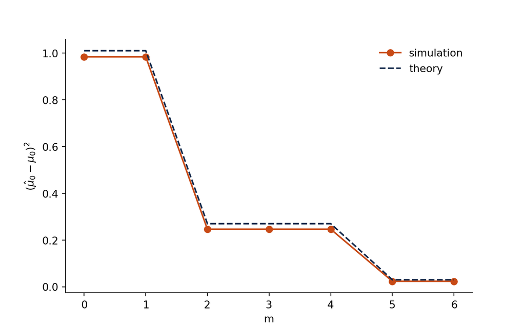

Squared prediction error at x0 vs model size.

```python
ax.spines[["top", "right"]].set_visible(False)
plt.show()
```

The simulation averages track the theory closely. The error stays near $1.01$ for $m=0,1$, drops to $0.27$ at $m=2$, holds through $m=4$, then falls to $0.03$ at $m=5$. The smallest $m$ that minimizes the theoretical error is $m=5$.

**c.** Even though all six $\beta_j$ are nonzero, $\mathbf x_0$ is zero in every coordinate except 2 and 5. The prediction is $\widehat\mu_{0,m} = \widehat\beta_0 + \sum_{j=1}^m x_{0j}\widehat\beta_j$, so any coefficient multiplied by a zero $x_{0j}$ drops out and never moves the prediction. Only $\widehat\beta_2$ and $\widehat\beta_5$ matter here. This is the difference from Question 1: there the test MSE averages error over all $n$ rows of $\mathbf X_{\mathrm{all}}$, so every predictor pulls its weight, whereas this target-specific error only cares about the predictors that are active at the one point $\mathbf x_0$.

## Question 3: The optimism correction

Choose one candidate model before observing the response. Let $p$ be its number of predictors and let $\mathbf X\in\mathbb R^{n\times(p+1)}$ be its full-rank design matrix, including the intercept. The model has $p+1$ fitted coefficients. Let

$$\mathbf H
=\mathbf X
(\mathbf X^{\mathsf T}\mathbf X)^{-1}
\mathbf X^{\mathsf T}$$

be its hat matrix. Suppose

$$\mathbf y=\boldsymbol\mu+\boldsymbol\epsilon,
\qquad
\mathbf y^*=\boldsymbol\mu+\boldsymbol\epsilon^*,$$

Conditional on the fixed design $\mathbf X$, the two error vectors are independent, have mean zero, and have covariance matrix $\sigma^2\mathbf I_n$. Define

$$\operatorname{MSE}_{\mathrm{train}}
=
\frac{1}{n}
\left\lVert
\mathbf y-\mathbf H\mathbf y
\right\rVert_2^2,
\qquad
\operatorname{MSE}_{\mathrm{test}}
=
\frac{1}{n}
\left\lVert
\mathbf y^*-\mathbf H\mathbf y
\right\rVert_2^2.$$

The conditional bias vector of the fitted mean is

$$E(\mathbf H\mathbf y\mid\mathbf X)-\boldsymbol\mu
=
-(\mathbf I_n-\mathbf H)\boldsymbol\mu.$$

Let $B^2$ denote the **total squared approximation bias**:

$$B^2
=\left\lVert
(\mathbf I_n-\mathbf H)\boldsymbol\mu
\right\rVert_2^2.$$

Thus, $B^2/n$ is the mean squared approximation bias.

You may use

$$\mathbf H^{\mathsf T}=\mathbf H,
\qquad
\mathbf H^2=\mathbf H,
\qquad
\operatorname{tr}(\mathbf H)=p+1.$$

For any fixed matrix $\mathbf A$, you may also use

$$E\!\left(
\boldsymbol\epsilon^{\mathsf T}
\mathbf A
\boldsymbol\epsilon
\mid \mathbf X
\right)
=\sigma^2\operatorname{tr}(\mathbf A).$$

1. Derive

$$E(\operatorname{MSE}_{\mathrm{train}}\mid\mathbf X)
=\frac{B^2}{n}
+\sigma^2\left(1-\frac{p+1}{n}\right),$$

and

$$E(\operatorname{MSE}_{\mathrm{test}}\mid\mathbf X)
=\frac{B^2}{n}
+\sigma^2\left(1+\frac{p+1}{n}\right).$$

2. Deduce the expected optimism, defined as $E(\operatorname{MSE}_{\mathrm{test}}-\operatorname{MSE}_{\mathrm{train}}\mid\mathbf X)$. For

$$n=120,
\qquad
p=4,
\qquad
\frac{B^2}{n}=0.04,
\qquad
\sigma^2=1,$$

calculate the expected training MSE, expected test MSE, and their difference. Explain why the ordering need not hold for every realized pair of responses.

3. Continue with $n=120$ and $p=4$. Suppose the candidate model has residual sum of squares $\operatorname{RSS}=116.4$, and suppose a common estimate of the error variance is $\widehat\sigma^2=0.96$.

Calculate

$$\widehat{\operatorname{MSE}}_{\mathrm{test}}
=\frac{
\operatorname{RSS}+2(p+1)\widehat\sigma^2
}{n},$$

and

$$C_p
=\frac{\operatorname{RSS}}{\widehat\sigma^2}
-n+2(p+1).$$

Show how these two quantities are related, and explain why minimizing $C_p$ is equivalent to minimizing the corrected test MSE when $n$ and $\widehat\sigma^2$ are common to all candidate models.

### My answer

**a.** *Training.* Write the training residual as
$$\mathbf y - \mathbf H\mathbf y = (\mathbf I - \mathbf H)\mathbf y = (\mathbf I - \mathbf H)\boldsymbol\mu + (\mathbf I - \mathbf H)\boldsymbol\epsilon,$$
using that $\mathbf y = \boldsymbol\mu + \boldsymbol\epsilon$. Let $\mathbf a = (\mathbf I - \mathbf H)\boldsymbol\mu$, so $\mathbf a^{\mathsf T}\mathbf a = B^2$. Then
$$\lVert(\mathbf I - \mathbf H)\mathbf y\rVert_2^2 = \mathbf a^{\mathsf T}\mathbf a + 2\,\mathbf a^{\mathsf T}(\mathbf I - \mathbf H)\boldsymbol\epsilon + \boldsymbol\epsilon^{\mathsf T}(\mathbf I - \mathbf H)\boldsymbol\epsilon,$$
where I used $(\mathbf I - \mathbf H)$ symmetric and idempotent. Taking $E(\cdot\mid\mathbf X)$: the cross term vanishes since $E(\boldsymbol\epsilon\mid\mathbf X)=\mathbf 0$, and $E(\boldsymbol\epsilon^{\mathsf T}(\mathbf I-\mathbf H)\boldsymbol\epsilon\mid\mathbf X) = \sigma^2\operatorname{tr}(\mathbf I - \mathbf H) = \sigma^2(n - (p+1))$. Dividing by $n$,
$$E(\operatorname{MSE}_{\mathrm{train}}\mid\mathbf X) = \frac{B^2}{n} + \sigma^2\left(1 - \frac{p+1}{n}\right).$$

*Test.* Here
$$\mathbf y^* - \mathbf H\mathbf y = (\mathbf I - \mathbf H)\boldsymbol\mu + \boldsymbol\epsilon^* - \mathbf H\boldsymbol\epsilon.$$
The three pieces are $\mathbf a$ (fixed), $\boldsymbol\epsilon^*$, and $-\mathbf H\boldsymbol\epsilon$, with $\boldsymbol\epsilon^*\perp\boldsymbol\epsilon$ and both mean zero, so every cross term drops in expectation. That leaves
$$E\lVert\cdot\rVert_2^2 = B^2 + E\lVert\boldsymbol\epsilon^*\rVert_2^2 + E\lVert\mathbf H\boldsymbol\epsilon\rVert_2^2 = B^2 + \sigma^2 n + \sigma^2(p+1),$$
using $E\lVert\mathbf H\boldsymbol\epsilon\rVert_2^2 = E(\boldsymbol\epsilon^{\mathsf T}\mathbf H\boldsymbol\epsilon\mid\mathbf X) = \sigma^2\operatorname{tr}(\mathbf H) = \sigma^2(p+1)$. Dividing by $n$,
$$E(\operatorname{MSE}_{\mathrm{test}}\mid\mathbf X) = \frac{B^2}{n} + \sigma^2\left(1 + \frac{p+1}{n}\right).$$

**b.** Subtracting, the bias terms cancel and the expected optimism is
$$E(\operatorname{MSE}_{\mathrm{test}} - \operatorname{MSE}_{\mathrm{train}}\mid\mathbf X) = \frac{2\sigma^2(p+1)}{n}.$$
With $n=120$, $p=4$, $B^2/n = 0.04$, $\sigma^2 = 1$:
$$E(\operatorname{MSE}_{\mathrm{train}}) = 0.04 + \left(1 - \tfrac{5}{120}\right) = 0.9983,\quad
E(\operatorname{MSE}_{\mathrm{test}}) = 0.04 + \left(1 + \tfrac{5}{120}\right) = 1.0817,$$
with difference $2(5)/120 = 0.0833$. This ordering is an expectation over the noise, not a guarantee for a single pair. Because $\mathbf H\mathbf y$ is fit to the *training* $\mathbf y$, one unlucky $\boldsymbol\epsilon^*$ (small test residual) or lucky split can flip the inequality on a given realization.

**c.** Plugging in $n=120$, $p=4$, $\operatorname{RSS}=116.4$, $\widehat\sigma^2 = 0.96$:
$$\widehat{\operatorname{MSE}}_{\mathrm{test}} = \frac{116.4 + 2(5)(0.96)}{120} = \frac{126}{120} = 1.05,\qquad
C_p = \frac{116.4}{0.96} - 120 + 2(5) = 11.25.$$
The two are the same quantity rescaled. Substituting $\operatorname{RSS} = \widehat\sigma^2\big(C_p + n - 2(p+1)\big)$ into $\widehat{\operatorname{MSE}}_{\mathrm{test}}$ gives
$$\widehat{\operatorname{MSE}}_{\mathrm{test}} = \frac{\widehat\sigma^2}{n}\,C_p + \widehat\sigma^2,$$
and indeed $\tfrac{0.96}{120}(11.25) + 0.96 = 1.05$. Since $\widehat\sigma^2/n > 0$ and both $\widehat\sigma^2/n$ and $\widehat\sigma^2$ are shared across all candidates (same $n$, same $\widehat\sigma^2$), $\widehat{\operatorname{MSE}}_{\mathrm{test}}$ is an increasing affine function of $C_p$, so whichever model minimizes one minimizes the other.

## Question 4: Comparing Mallows’ $C_p$, AIC, and BIC

Use `data/diabetes.csv`, with `y` as the response. Use rows 1 through 370 as the training data, and let $n=370$ denote the training sample size. Do not use rows 371 through 442 in this question. Fit the following ordinary least-squares models, each with an intercept.

| Model | Predictors | $p$ |
| --- | --- | --- |
| Model A | `bmi`, `bp`, `s5`, `sex`, `s1`, `s2`, `s4` | 7 |
| Model B | all predictors in Model A, followed by `s6` | 8 |
| Full reference | all ten predictors | 10 |

Here $p$ counts predictors, so each model has $p+1$ fitted coefficients including the intercept. Estimate one common noise variance from the full reference model, using $p=10$:

$$\widehat\sigma^2
=\frac{\operatorname{RSS}_{\mathrm{full}}}{n-(p+1)}.$$

For Models A and B, calculate

$$C_p
=\frac{\operatorname{RSS}}{\widehat\sigma^2}
-n+2(p+1),$$

$$\operatorname{AIC}^{\mathrm{red}}
=n\log\left(\frac{\operatorname{RSS}}{n}\right)+2(p+1),$$

and

$$\operatorname{BIC}^{\mathrm{red}}
=n\log\left(\frac{\operatorname{RSS}}{n}\right)
+(p+1)\log(n).$$

The reduced AIC and BIC omit constants shared by the two candidate models. Smaller values are preferred within each criterion.

1. Fit the three models. Report $p$, RSS, the residual degrees of freedom of the full model, and $\widehat\sigma^2$.
2. Calculate $C_p$, reduced AIC, and reduced BIC for Models A and B. State which model each criterion selects. Do not compare numerical values across different criteria.
3. Compare the improvement in fit from adding `s6` with the one-parameter penalty under each criterion. Use this comparison to explain any disagreement. Why does selecting a model not establish that it is the true data-generating model?

### My answer

**Show the starter code**

```python
import numpy as np
import pandas as pd

df = pd.read_csv("data/diabetes.csv")
train = df.iloc[:370]
n = 370
y = train["y"].values

def rss(cols):
    X = np.column_stack([np.ones(n), train[cols].values])
    b, *_ = np.linalg.lstsq(X, y, rcond=None)
    r = y - X @ b
    return r @ r

A = ["bmi", "bp", "s5", "sex", "s1", "s2", "s4"]
B = A + ["s6"]
full = ["age", "sex", "bmi", "bp", "s1", "s2", "s3", "s4", "s5", "s6"]

rss_A, rss_B, rss_full = rss(A), rss(B), rss(full)
sigma2 = rss_full / (n - (10 + 1))
print(f"RSS_full = {rss_full:.1f}   dof_full = {n - 11}   sigma2_hat = {sigma2:.2f}")
```

```
RSS_full = 1089451.7   dof_full = 359   sigma2_hat = 3034.68
```

**Show the starter code**

```python
def criteria(r, p):
    Cp = r / sigma2 - n + 2 * (p + 1)
    aic = n * np.log(r / n) + 2 * (p + 1)
    bic = n * np.log(r / n) + (p + 1) * np.log(n)
    return Cp, aic, bic

for name, r, p in [("A", rss_A, 7), ("B", rss_B, 8)]:
    Cp, aic, bic = criteria(r, p)
    print(f"Model {name}: p={p} RSS={r:.1f}  Cp={Cp:.3f}  AICred={aic:.2f}  BICred={bic:.2f}")
```

```
Model A: p=7 RSS=1098908.6  Cp=8.116  AICred=2974.64  BICred=3005.95
Model B: p=8 RSS=1089717.1  Cp=7.087  AICred=2973.53  BICred=3008.75
```

**Show the starter code**

```python
print("RSS drop from adding s6:", round(rss_A - rss_B, 1))
```

```
RSS drop from adding s6: 9191.5
```

**a.** The full 10-predictor reference has $\operatorname{RSS}_{\mathrm{full}} \approx 1{,}089{,}452$ with $n-(p+1) = 370 - 11 = 359$ residual degrees of freedom, giving $\widehat\sigma^2 = \operatorname{RSS}_{\mathrm{full}}/359 \approx 3034.68$. Model A ($p=7$) has $\operatorname{RSS}\approx 1{,}098{,}909$ and Model B ($p=8$) has $\operatorname{RSS}\approx 1{,}089{,}717$.

**b.** The criteria come out to:

| Model | $C_p$ | reduced AIC | reduced BIC |
| --- | --- | --- | --- |
| A ($p=7$) | 8.116 | 2974.64 | 3005.95 |
| B ($p=8$) | 7.087 | 2973.53 | 3008.75 |

$C_p$ and reduced AIC both prefer Model B (smaller values), while reduced BIC prefers Model A.

**c.** Adding `s6` cuts RSS by about $9192$. In criterion units that improvement is worth $9192/\widehat\sigma^2 \approx 3.03$ for $C_p$, against a penalty of $2$ for the one extra coefficient, so $C_p$ says the swap is worth it (net $\approx -1.0$). AIC sees essentially the same trade (fit gain $\approx 3.1$ in deviance, penalty $+2$) and also picks B. BIC charges $\log(370) \approx 5.9$ per parameter, which is more than the $3.1$ gain, so BIC keeps the smaller Model A. The disagreement is entirely about how steeply each criterion prices an added predictor: BIC penalizes complexity harder as $n$ grows. And selecting a model does not make it the true one. These criteria only estimate out-of-sample prediction error under modeling assumptions; the “best” of a short candidate list is just the best available compromise, not evidence that its predictor set is the real data-generating mechanism.

## Question 5: Validation and final test data

Use rows 1 through 370 of `diabetes.csv` as the training data and rows 371 through 442 as the final test data. Consider eleven nested candidate models. For $m=0,1,\ldots,10$, the model with $m$ predictors contains an intercept and the first $m$ predictors in this order:

`age`, `sex`, `bmi`, `bp`, `s1`, `s2`, `s3`, `s4`, `s5`, `s6`.

An analyst proposes the following procedure:

1. Fit all eleven candidate models using the training data.
2. Calculate the MSE of each model on the final test data.
3. Select the model with the smallest test MSE.
4. Report that minimum as the final estimate of prediction error.

The analyst argues that the procedure is valid because the final test data were not used to estimate the regression coefficients.

1. Identify the first step that misuses the final test data. Explain why the minimum of eleven test MSE values is generally too favorable as an estimate of the selected procedure’s future prediction error.
2. Rewrite the analysis using five-fold cross-validation within the training data. State how the predictor count is selected, what is refitted, and when the final test data may be used.
3. Suppose the analyst has already examined all eleven test MSE values. What can still be reported transparently, and what additional data would be needed for a new final evaluation?

### My answer

**a.** The misuse lands at step 3, where the model is chosen by smallest test MSE. Computing the eleven MSEs in step 2 is harmless on its own; it’s picking the argmin that lets the final test set drive selection rather than just estimation, which is what the analyst’s defense (“it wasn’t used to fit coefficients”) misses. The number reported in step 4 is then too optimistic: it’s the minimum of eleven noisy MSE values, and taking the min of several estimates systematically lands below the true error of the selected procedure. You end up reporting whichever model got the luckiest test draw, so its test MSE understates how it will do on genuinely new data.

**b.** Keep the final test rows (371 through 442) locked away and do the selection inside the training rows (1 through 370) with 5-fold CV. Split the 370 training rows into 5 folds. For each candidate size $m = 0,\ldots,10$, fit on 4 folds and record MSE on the held-out fold, cycling so each fold is held out once, then average the 5 fold-MSEs into $\mathrm{CV}(m)$. Choose $m^\star = \arg\min_m \mathrm{CV}(m)$. Refit that one model on all 370 training rows. Only after $m^\star$ is fixed do you touch rows 371 through 442, exactly once, to report the final prediction error.

**c.** Since all eleven test MSEs have already been looked at, that test set is spent for an honest final number. What’s still fair to report transparently: the full table of the eleven test MSEs, labeled as exploratory rather than a single selected error, plus a proper CV-based selection carried out on the training data alone. For a clean, unbiased final evaluation of whatever model you settle on, you’d need a fresh block of held-out data that played no role in any selection step.

## Reference

James, Witten, Hastie, Tibshirani, and Taylor, [*An Introduction to Statistical Learning*](https://www.statlearning.com/), Chapters 3, 5, and 6.